# (Ford-GoBike Share)

## Preliminary Wrangling

> This data set includes information about individual rides made in a bike-sharing system covering the greater San Francisco Bay area. Time and dates at which riders used to go on a ride, also some members identifications like age and membership status are included as well for each member. To analyze the main factors upon which may or may not affect the duration the individual take during the trip.

```python
# import all packages and set plots to be embedded inline
import numpy as np
import pandas as pd
import matplotlib.pyplot as plt
import seaborn as sb
from datetime import datetime, timedelta

%matplotlib inline
```

> Load in your dataset and describe its properties through the questions below. Try and motivate your exploration goals through this section.

```python
df = pd.read_csv('E://z/2019-fordgobike-San Franscisco.csv')
df.head()
```

|  | duration_sec | start_time | end_time | start_station_id | start_station_name | start_station_latitude | start_station_longitude | end_station_id | end_station_name | end_station_latitude | end_station_longitude | bike_id | user_type | member_birth_year | member_gender | bike_share_for_all_trip |
| --- | --- | --- | --- | --- | --- | --- | --- | --- | --- | --- | --- | --- | --- | --- | --- | --- |
| 183407 | 480 | 2019-02-01 00:04:49.7240 | 2019-02-01 00:12:50.0340 | 27.0 | Beale St at Harrison St | 37.788059 | -122.391865 | 324.0 | Union Square (Powell St at Post St) | 37.788300 | -122.408531 | 4832 | Subscriber | 1996.0 | Male | No |
| 183408 | 313 | 2019-02-01 00:05:34.7440 | 2019-02-01 00:10:48.5020 | 21.0 | Montgomery St BART Station (Market St at 2nd St) | 37.789625 | -122.400811 | 66.0 | 3rd St at Townsend St | 37.778742 | -122.392741 | 4960 | Subscriber | 1984.0 | Male | No |
| 183409 | 141 | 2019-02-01 00:06:05.5490 | 2019-02-01 00:08:27.2200 | 278.0 | The Alameda at Bush St | 37.331932 | -121.904888 | 277.0 | Morrison Ave at Julian St | 37.333658 | -121.908586 | 3824 | Subscriber | 1990.0 | Male | Yes |
| 183410 | 139 | 2019-02-01 00:05:34.3600 | 2019-02-01 00:07:54.2870 | 220.0 | San Pablo Ave at MLK Jr Way | 37.811351 | -122.273422 | 216.0 | San Pablo Ave at 27th St | 37.817827 | -122.275698 | 5095 | Subscriber | 1988.0 | Male | No |
| 183411 | 271 | 2019-02-01 00:00:20.6360 | 2019-02-01 00:04:52.0580 | 24.0 | Spear St at Folsom St | 37.789677 | -122.390428 | 37.0 | 2nd St at Folsom St | 37.785000 | -122.395936 | 1057 | Subscriber | 1989.0 | Male | No |

```python
# shape of the data
df.shape
```

```
(183412, 16)
```

```python
# Defining column's names to decide which are the most important
df.columns
```

```
Index(['duration_sec', 'start_time', 'end_time', 'start_station_id',
       'start_station_name', 'start_station_latitude',
       'start_station_longitude', 'end_station_id', 'end_station_name',
       'end_station_latitude', 'end_station_longitude', 'bike_id', 'user_type',
       'member_birth_year', 'member_gender', 'bike_share_for_all_trip'],
      dtype='object')
```

```python
# general idea about each column
df.info()
```

```
<class 'pandas.core.frame.DataFrame'>
RangeIndex: 183412 entries, 0 to 183411
Data columns (total 16 columns):
 #   Column                   Non-Null Count   Dtype
---  ------                   --------------   -----
 0   duration_sec             183412 non-null  int64
 1   start_time               183412 non-null  object
 2   end_time                 183412 non-null  object
 3   start_station_id         183215 non-null  float64
 4   start_station_name       183215 non-null  object
 5   start_station_latitude   183412 non-null  float64
 6   start_station_longitude  183412 non-null  float64
 7   end_station_id           183215 non-null  float64
 8   end_station_name         183215 non-null  object
 9   end_station_latitude     183412 non-null  float64
 10  end_station_longitude    183412 non-null  float64
 11  bike_id                  183412 non-null  int64
 12  user_type                183412 non-null  object
 13  member_birth_year        175147 non-null  float64
 14  member_gender            175147 non-null  object
 15  bike_share_for_all_trip  183412 non-null  object
dtypes: float64(7), int64(2), object(7)
memory usage: 22.4+ MB
```

```python
# Is there any Null values
df.isnull().sum()
```

```
duration_sec                  0
start_time                    0
end_time                      0
start_station_id            197
start_station_name          197
start_station_latitude        0
start_station_longitude       0
end_station_id              197
end_station_name            197
end_station_latitude          0
end_station_longitude         0
bike_id                       0
user_type                     0
member_birth_year          8265
member_gender              8265
bike_share_for_all_trip       0
dtype: int64
```

```python
#Removing Null values
df.dropna(inplace=True)
```

```python
#New Shape after cleaning
df.shape
```

```
(174952, 16)
```

```python
# Converting bike_id column to an object to not confused as an effective numeric while analysing
df['bike_id']=df['bike_id'].apply(str)
```

```python
df['bike_id'].duplicated().sum()
```

```
170345
```

```python
# See if each bike ID has been repeated and how many
df['bike_id'].value_counts()
```

```
4794    179
4814    172
5175    167
4450    166
5145    165
       ...
992       1
50        1
6061      1
6271      1
350       1
Name: bike_id, Length: 4607, dtype: int64
```

```python
# Duplicated bike ID's
df['bike_id'].duplicated().count()
```

```
174952
```

**After Some exploration to the data we going to remove the unwanted columns**

```python
df.drop(['start_station_id','start_station_latitude','start_station_longitude',
        'end_station_id','end_station_latitude','end_station_longitude'],axis=1,inplace=True)
```

```python
df.head(10)
```

|  | duration_sec | start_time | end_time | start_station_name | end_station_name | bike_id | user_type | member_birth_year | member_gender | bike_share_for_all_trip |
| --- | --- | --- | --- | --- | --- | --- | --- | --- | --- | --- |
| 0 | 52185 | 2019-02-28 17:32:10.1450 | 2019-03-01 08:01:55.9750 | Montgomery St BART Station (Market St at 2nd St) | Commercial St at Montgomery St | 4902 | Customer | 1984.0 | Male | No |
| 2 | 61854 | 2019-02-28 12:13:13.2180 | 2019-03-01 05:24:08.1460 | Market St at Dolores St | Powell St BART Station (Market St at 4th St) | 5905 | Customer | 1972.0 | Male | No |
| 3 | 36490 | 2019-02-28 17:54:26.0100 | 2019-03-01 04:02:36.8420 | Grove St at Masonic Ave | Central Ave at Fell St | 6638 | Subscriber | 1989.0 | Other | No |
| 4 | 1585 | 2019-02-28 23:54:18.5490 | 2019-03-01 00:20:44.0740 | Frank H Ogawa Plaza | 10th Ave at E 15th St | 4898 | Subscriber | 1974.0 | Male | Yes |
| 5 | 1793 | 2019-02-28 23:49:58.6320 | 2019-03-01 00:19:51.7600 | 4th St at Mission Bay Blvd S | Broadway at Kearny | 5200 | Subscriber | 1959.0 | Male | No |
| 6 | 1147 | 2019-02-28 23:55:35.1040 | 2019-03-01 00:14:42.5880 | Palm St at Willow St | San Jose Diridon Station | 3803 | Subscriber | 1983.0 | Female | No |
| 7 | 1615 | 2019-02-28 23:41:06.7660 | 2019-03-01 00:08:02.7560 | Washington St at Kearny St | Valencia St at 21st St | 6329 | Subscriber | 1989.0 | Male | No |
| 8 | 1570 | 2019-02-28 23:41:48.7900 | 2019-03-01 00:07:59.7150 | Washington St at Kearny St | Valencia St at 21st St | 6548 | Subscriber | 1988.0 | Other | No |
| 9 | 1049 | 2019-02-28 23:49:47.6990 | 2019-03-01 00:07:17.0250 | Post St at Kearny St | Mission Playground | 6488 | Subscriber | 1992.0 | Male | No |
| 10 | 458 | 2019-02-28 23:57:57.2110 | 2019-03-01 00:05:35.4350 | Jones St at Post St | San Francisco Public Library (Grove St at Hyde... | 5318 | Subscriber | 1996.0 | Female | Yes |

```python
end_time = pd.to_datetime(df['end_time'])
start_time = pd.to_datetime(df['start_time'])
```

```python
df['duration_hrs'] = end_time - start_time
```

```python
df.head()
```

|  | duration_sec | start_time | end_time | start_station_name | end_station_name | bike_id | user_type | member_birth_year | member_gender | bike_share_for_all_trip | duration_hrs |
| --- | --- | --- | --- | --- | --- | --- | --- | --- | --- | --- | --- |
| 0 | 52185 | 2019-02-28 17:32:10.1450 | 2019-03-01 08:01:55.9750 | Montgomery St BART Station (Market St at 2nd St) | Commercial St at Montgomery St | 4902 | Customer | 1984.0 | Male | No | 0 days 14:29:45.830000 |
| 2 | 61854 | 2019-02-28 12:13:13.2180 | 2019-03-01 05:24:08.1460 | Market St at Dolores St | Powell St BART Station (Market St at 4th St) | 5905 | Customer | 1972.0 | Male | No | 0 days 17:10:54.928000 |
| 3 | 36490 | 2019-02-28 17:54:26.0100 | 2019-03-01 04:02:36.8420 | Grove St at Masonic Ave | Central Ave at Fell St | 6638 | Subscriber | 1989.0 | Other | No | 0 days 10:08:10.832000 |
| 4 | 1585 | 2019-02-28 23:54:18.5490 | 2019-03-01 00:20:44.0740 | Frank H Ogawa Plaza | 10th Ave at E 15th St | 4898 | Subscriber | 1974.0 | Male | Yes | 0 days 00:26:25.525000 |
| 5 | 1793 | 2019-02-28 23:49:58.6320 | 2019-03-01 00:19:51.7600 | 4th St at Mission Bay Blvd S | Broadway at Kearny | 5200 | Subscriber | 1959.0 | Male | No | 0 days 00:29:53.128000 |

```python
df['duration_hrs'].describe()
```

```
count                       174952
mean     0 days 00:11:44.501722849
std      0 days 00:27:22.204402191
min         0 days 00:01:01.081000
25%         0 days 00:05:23.425750
50%         0 days 00:08:30.852500
75%         0 days 00:13:09.224500
max         0 days 23:29:08.051000
Name: duration_hrs, dtype: object
```

```python
# Extracting day of week and hours
```

```python
df['start_time']=pd.to_datetime(df['start_time'])
df['start_date']= df.start_time.dt.date
df['start_day'] = pd.to_datetime(df['start_time']).dt.day_name()
df['start_hour'] = pd.to_datetime(df['start_time']).dt.hour
```

```python
df['end_time']=pd.to_datetime(df['end_time'])
df['end_date'] =  df.end_time.dt.date
df['end_day'] = pd.to_datetime(df['end_time']).dt.day_name()
df['end_hour'] = pd.to_datetime(df['end_time']).dt.hour
```

```python
df.head()
```

|  | duration_sec | start_time | end_time | start_station_name | end_station_name | bike_id | user_type | member_birth_year | member_gender | bike_share_for_all_trip | duration_hrs | start_date | start_day | start_hour | end_date | end_day | end_hour |
| --- | --- | --- | --- | --- | --- | --- | --- | --- | --- | --- | --- | --- | --- | --- | --- | --- | --- |
| 0 | 52185 | 2019-02-28 17:32:10.145 | 2019-03-01 08:01:55.975 | Montgomery St BART Station (Market St at 2nd St) | Commercial St at Montgomery St | 4902 | Customer | 1984.0 | Male | No | 0 days 14:29:45.830000 | 2019-02-28 | Thursday | 17 | 2019-03-01 | Friday | 8 |
| 2 | 61854 | 2019-02-28 12:13:13.218 | 2019-03-01 05:24:08.146 | Market St at Dolores St | Powell St BART Station (Market St at 4th St) | 5905 | Customer | 1972.0 | Male | No | 0 days 17:10:54.928000 | 2019-02-28 | Thursday | 12 | 2019-03-01 | Friday | 5 |
| 3 | 36490 | 2019-02-28 17:54:26.010 | 2019-03-01 04:02:36.842 | Grove St at Masonic Ave | Central Ave at Fell St | 6638 | Subscriber | 1989.0 | Other | No | 0 days 10:08:10.832000 | 2019-02-28 | Thursday | 17 | 2019-03-01 | Friday | 4 |
| 4 | 1585 | 2019-02-28 23:54:18.549 | 2019-03-01 00:20:44.074 | Frank H Ogawa Plaza | 10th Ave at E 15th St | 4898 | Subscriber | 1974.0 | Male | Yes | 0 days 00:26:25.525000 | 2019-02-28 | Thursday | 23 | 2019-03-01 | Friday | 0 |
| 5 | 1793 | 2019-02-28 23:49:58.632 | 2019-03-01 00:19:51.760 | 4th St at Mission Bay Blvd S | Broadway at Kearny | 5200 | Subscriber | 1959.0 | Male | No | 0 days 00:29:53.128000 | 2019-02-28 | Thursday | 23 | 2019-03-01 | Friday | 0 |

```python
df.shape
```

```
(174952, 17)
```

```python
df['age']= (2019- df['member_birth_year'])
```

```python
df.head(10)
```

|  | duration_sec | start_time | end_time | start_station_name | end_station_name | bike_id | user_type | member_birth_year | member_gender | bike_share_for_all_trip | duration_hrs | start_date | start_day | start_hour | end_date | end_day | end_hour | age |
| --- | --- | --- | --- | --- | --- | --- | --- | --- | --- | --- | --- | --- | --- | --- | --- | --- | --- | --- |
| 0 | 52185 | 2019-02-28 17:32:10.145 | 2019-03-01 08:01:55.975 | Montgomery St BART Station (Market St at 2nd St) | Commercial St at Montgomery St | 4902 | Customer | 1984.0 | Male | No | 0 days 14:29:45.830000 | 2019-02-28 | Thursday | 17 | 2019-03-01 | Friday | 8 | 35.0 |
| 2 | 61854 | 2019-02-28 12:13:13.218 | 2019-03-01 05:24:08.146 | Market St at Dolores St | Powell St BART Station (Market St at 4th St) | 5905 | Customer | 1972.0 | Male | No | 0 days 17:10:54.928000 | 2019-02-28 | Thursday | 12 | 2019-03-01 | Friday | 5 | 47.0 |
| 3 | 36490 | 2019-02-28 17:54:26.010 | 2019-03-01 04:02:36.842 | Grove St at Masonic Ave | Central Ave at Fell St | 6638 | Subscriber | 1989.0 | Other | No | 0 days 10:08:10.832000 | 2019-02-28 | Thursday | 17 | 2019-03-01 | Friday | 4 | 30.0 |
| 4 | 1585 | 2019-02-28 23:54:18.549 | 2019-03-01 00:20:44.074 | Frank H Ogawa Plaza | 10th Ave at E 15th St | 4898 | Subscriber | 1974.0 | Male | Yes | 0 days 00:26:25.525000 | 2019-02-28 | Thursday | 23 | 2019-03-01 | Friday | 0 | 45.0 |
| 5 | 1793 | 2019-02-28 23:49:58.632 | 2019-03-01 00:19:51.760 | 4th St at Mission Bay Blvd S | Broadway at Kearny | 5200 | Subscriber | 1959.0 | Male | No | 0 days 00:29:53.128000 | 2019-02-28 | Thursday | 23 | 2019-03-01 | Friday | 0 | 60.0 |
| 6 | 1147 | 2019-02-28 23:55:35.104 | 2019-03-01 00:14:42.588 | Palm St at Willow St | San Jose Diridon Station | 3803 | Subscriber | 1983.0 | Female | No | 0 days 00:19:07.484000 | 2019-02-28 | Thursday | 23 | 2019-03-01 | Friday | 0 | 36.0 |
| 7 | 1615 | 2019-02-28 23:41:06.766 | 2019-03-01 00:08:02.756 | Washington St at Kearny St | Valencia St at 21st St | 6329 | Subscriber | 1989.0 | Male | No | 0 days 00:26:55.990000 | 2019-02-28 | Thursday | 23 | 2019-03-01 | Friday | 0 | 30.0 |
| 8 | 1570 | 2019-02-28 23:41:48.790 | 2019-03-01 00:07:59.715 | Washington St at Kearny St | Valencia St at 21st St | 6548 | Subscriber | 1988.0 | Other | No | 0 days 00:26:10.925000 | 2019-02-28 | Thursday | 23 | 2019-03-01 | Friday | 0 | 31.0 |
| 9 | 1049 | 2019-02-28 23:49:47.699 | 2019-03-01 00:07:17.025 | Post St at Kearny St | Mission Playground | 6488 | Subscriber | 1992.0 | Male | No | 0 days 00:17:29.326000 | 2019-02-28 | Thursday | 23 | 2019-03-01 | Friday | 0 | 27.0 |
| 10 | 458 | 2019-02-28 23:57:57.211 | 2019-03-01 00:05:35.435 | Jones St at Post St | San Francisco Public Library (Grove St at Hyde... | 5318 | Subscriber | 1996.0 | Female | Yes | 0 days 00:07:38.224000 | 2019-02-28 | Thursday | 23 | 2019-03-01 | Friday | 0 | 23.0 |

### What is/are the main feature(s) of interest in your dataset?

**The main features are Trip Duration, user_type, Gender, Age, And Start Time**

### What features in the dataset do you think will help support your investigation into your feature(s) of interest?

**The age, start hour and the common days of the week plus duration will be a great asset in this investigation and will help me out identify the rush hours and the most common points may need to be developed and focused on due to high bikers rate initiate from this point and, And also Gender will be usfull to identify which gender more prone to use the bikeshare upon which we can make decisions about the next campagin for focusing to attract more men or mon females**

## Univariate Exploration

> In this section, investigate distributions of individual variables. If you see unusual points or outliers, take a deeper look to clean things up and prepare yourself to look at relationships between variables.

```python
# Due to having too much starting points we will use the most 50 frequent start stations

count = df['start_station_name'].value_counts()
```

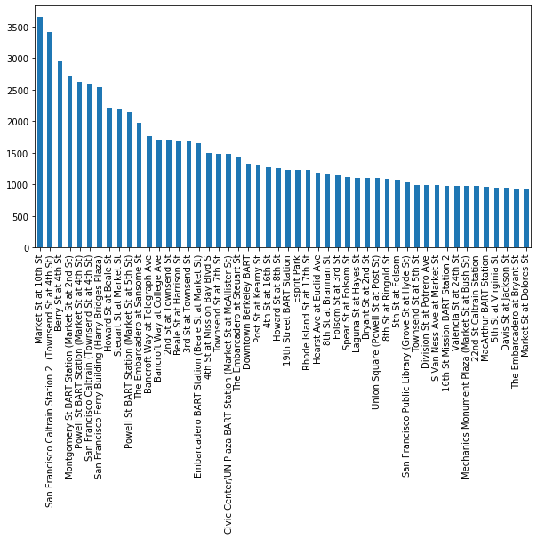

```python
plt.figure(figsize=(10,5))
df['start_station_name'].value_counts()[:50].plot(kind='bar');
```

```python
# Due to having too much ending point we will use the most 50 frequest start stations
count = df['end_station_name'].value_counts()
```

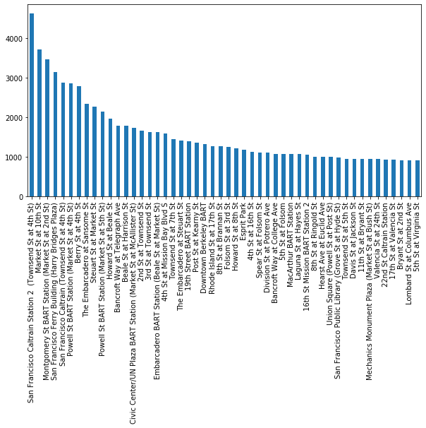

```python
plt.figure(figsize=(10,5))
df['end_station_name'].value_counts()[:50].plot(kind='bar');
```

```python
# Describe duration column, defining min,max, and duration mean
df['duration_sec'].describe()
```

```
count    174952.000000
mean        704.002744
std        1642.204905
min          61.000000
25%         323.000000
50%         510.000000
75%         789.000000
max       84548.000000
Name: duration_sec, dtype: float64
```

```python
# duration mean in minutes
duration_mean = 704 / 60
print('Duration mean is: ', duration_mean)
```

```
Duration mean is:  11.733333333333333
```

```python
# getting the log base 10 to the minimum duration
np.log10(61)
```

```
1.7853298350107671
```

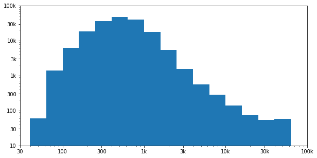

```python
# Plotting Duration in sec
plt.figure(figsize=(10,5))
bin = 10**np.arange(1,np.log10(df['duration_sec'].max()+.2),.2)
plt.hist(data=df,x='duration_sec',bins=bin);
plt.xscale('log');
plt.yscale('log')
plt.xticks([10, 30, 100, 300, 1000,3000,10000,30000,100000], ['10','30','100','300', '1k','3k', '10k', '30k', '100k'])
#x_ticks = [0.3,1,3,10,30,100,300,1000,3000,10000,100000]
plt.yticks([10, 30, 100, 300, 1000,3000,10000,30000,100000], ['10','30','100','300', '1k','3k', '10k', '30k', '100k']);
plt.xlim((30,100000));
```

#### Most duration falls in the zone between (300 - 2000 sec)

### Supposed that bike_ID is related to a specific type of bike(which is an information we dont have), we can do a bar plot and see how many times each bike has been used during this month

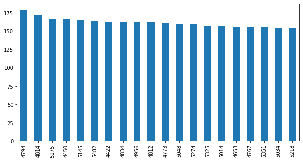

```python
plt.figure(figsize=(10,5))
df['bike_id'].value_counts()[:20].plot(kind='bar');
```

**We found out the bikes with ID (4794,4814) are the most used bikes**

```python
# Describe age column getting min,max and the mean age
df['age'].describe()
```

```
count    174952.000000
mean         34.196865
std          10.118731
min          18.000000
25%          27.000000
50%          32.000000
75%          39.000000
max         141.000000
Name: age, dtype: float64
```

### The mean age for the bike riders is around 34 years old, and we found out an anomoly that the max age is 141 which is not right value

```python
df[df['age'] > 100]
```

|  | duration_sec | start_time | end_time | start_station_name | end_station_name | bike_id | user_type | member_birth_year | member_gender | bike_share_for_all_trip | duration_hrs | start_date | start_day | start_hour | end_date | end_day | end_hour | age |
| --- | --- | --- | --- | --- | --- | --- | --- | --- | --- | --- | --- | --- | --- | --- | --- | --- | --- | --- |
| 1285 | 148 | 2019-02-28 19:29:17.627 | 2019-02-28 19:31:45.967 | Shattuck Ave at Telegraph Ave | Shattuck Ave at 55th St | 5391 | Subscriber | 1900.0 | Male | Yes | 0 days 00:02:28.340000 | 2019-02-28 | Thursday | 19 | 2019-02-28 | Thursday | 19 | 119.0 |
| 10827 | 1315 | 2019-02-27 19:21:34.436 | 2019-02-27 19:43:30.008 | Bryant St at 2nd St | Grove St at Masonic Ave | 6249 | Subscriber | 1900.0 | Male | No | 0 days 00:21:55.572000 | 2019-02-27 | Wednesday | 19 | 2019-02-27 | Wednesday | 19 | 119.0 |
| 16087 | 1131 | 2019-02-27 08:37:36.864 | 2019-02-27 08:56:28.022 | Grove St at Masonic Ave | Folsom St at 3rd St | 4968 | Subscriber | 1900.0 | Male | No | 0 days 00:18:51.158000 | 2019-02-27 | Wednesday | 8 | 2019-02-27 | Wednesday | 8 | 119.0 |
| 19375 | 641 | 2019-02-26 17:03:19.855 | 2019-02-26 17:14:01.619 | Broadway at Battery St | San Francisco Caltrain (Townsend St at 4th St) | 6164 | Customer | 1900.0 | Male | No | 0 days 00:10:41.764000 | 2019-02-26 | Tuesday | 17 | 2019-02-26 | Tuesday | 17 | 119.0 |
| 21424 | 1424 | 2019-02-26 08:58:02.904 | 2019-02-26 09:21:47.749 | Grove St at Masonic Ave | Bryant St at 2nd St | 5344 | Subscriber | 1900.0 | Male | No | 0 days 00:23:44.845000 | 2019-02-26 | Tuesday | 8 | 2019-02-26 | Tuesday | 9 | 119.0 |
| ... | ... | ... | ... | ... | ... | ... | ... | ... | ... | ... | ... | ... | ... | ... | ... | ... | ... | ... |
| 171996 | 1368 | 2019-02-03 17:33:54.607 | 2019-02-03 17:56:42.949 | 2nd St at Folsom St | Grove St at Masonic Ave | 4988 | Subscriber | 1900.0 | Male | No | 0 days 00:22:48.342000 | 2019-02-03 | Sunday | 17 | 2019-02-03 | Sunday | 17 | 119.0 |
| 173711 | 993 | 2019-02-03 09:45:30.464 | 2019-02-03 10:02:04.169 | Grove St at Masonic Ave | Folsom St at 3rd St | 5445 | Subscriber | 1900.0 | Male | No | 0 days 00:16:33.705000 | 2019-02-03 | Sunday | 9 | 2019-02-03 | Sunday | 10 | 119.0 |
| 177708 | 1527 | 2019-02-01 19:09:28.387 | 2019-02-01 19:34:55.963 | Bryant St at 2nd St | Grove St at Masonic Ave | 5286 | Subscriber | 1900.0 | Male | No | 0 days 00:25:27.576000 | 2019-02-01 | Friday | 19 | 2019-02-01 | Friday | 19 | 119.0 |
| 177885 | 517 | 2019-02-01 18:38:40.471 | 2019-02-01 18:47:18.392 | Howard St at 2nd St | San Francisco Caltrain (Townsend St at 4th St) | 2175 | Subscriber | 1902.0 | Female | No | 0 days 00:08:37.921000 | 2019-02-01 | Friday | 18 | 2019-02-01 | Friday | 18 | 117.0 |
| 182830 | 428 | 2019-02-01 07:45:05.934 | 2019-02-01 07:52:14.922 | Yerba Buena Center for the Arts (Howard St at ... | San Francisco Caltrain Station 2 (Townsend St... | 5031 | Subscriber | 1901.0 | Male | No | 0 days 00:07:08.988000 | 2019-02-01 | Friday | 7 | 2019-02-01 | Friday | 7 | 118.0 |

72 rows × 18 columns

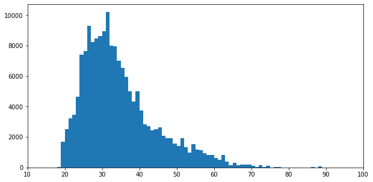

```python
# plotting age column
plt.figure(figsize=(10,5))
bin = np.arange(15,100+1,1)
plt.hist(data=df,x='age',bins=bin
        );
plt.xlim((10,100));
```

### we found out that we have 72 rows of age over 100 years old, so I decided to keep the rows to not remove other useful features from the data, and because they are doesn't affect our histogram interpretation

```python
# Getting the proprtion of each gender
```

```python
counts = df.member_gender.value_counts()
```

```python
total = df.member_gender.value_counts().sum()
```

```python
male_prop = df.member_gender.value_counts()[0] / total
female_prop = df.member_gender.value_counts()[1] / total
other_prop = df.member_gender.value_counts()[2] /total
other_prop
male_prop
```

```
0.7459188806072523
```

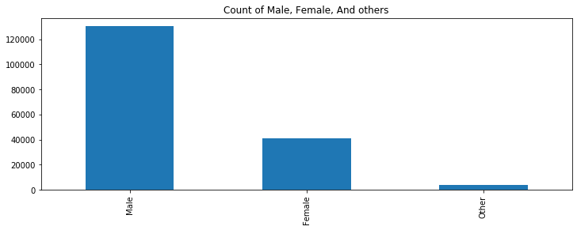

```python
# Counting how many male, female, and others contributed.showing the percentage
df.member_gender.value_counts().plot(kind='bar',title='Count of Male, Female, And others');
```

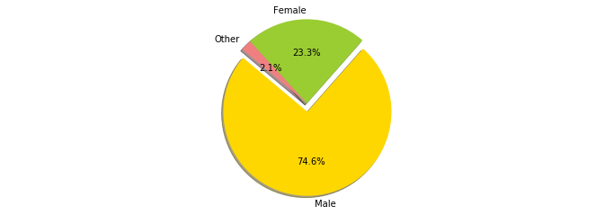

```python
# showing percentage of each gender
labels = 'Male', 'Female', 'Other'
sizes = [male_prop,female_prop,other_prop]
colors = ['gold', 'yellowgreen', 'lightcoral']
explode = (0.1, 0, 0)  # explode 1st slice

# Plot
plt.pie(sizes, explode=explode, labels=labels, colors=colors,
autopct='%1.1f%%', shadow=True, startangle=140)

plt.axis('equal')
plt.show()
```

#### Obviously the male has the most dominant count over female and other in this dataset, in the next plots we will consider this difference and see what if this male count dmoinancy has the same high frequency according to the other factors like duration of the trip

```python
# describing the start hour column looking for min,max and the mean
df['start_hour'].describe()
```

```
count    174952.000000
mean         13.456165
std           4.734282
min           0.000000
25%           9.000000
50%          14.000000
75%          17.000000
max          23.000000
Name: start_hour, dtype: float64
```

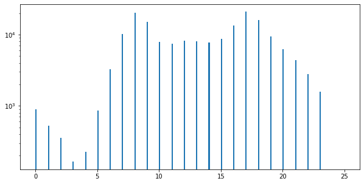

```python
bin = np.arange(0,25+.1,.1)
plt.figure(figsize=(10,5))

plt.hist(data=df,x='start_hour',bins = bin);
plt.yscale('log')
```

#### We saw that the most common starting hours is 8 Am, and 5 Pm

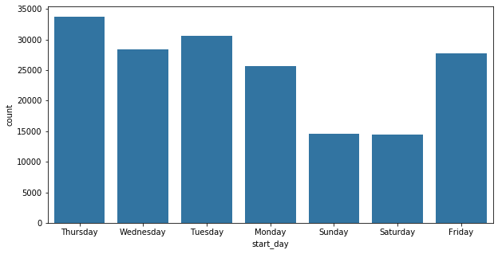

```python
# the most common start_day

plt.figure(figsize=(10,5))
base_color = sb.color_palette()[0]
sb.countplot(data=df,x='start_day',color=base_color);
```

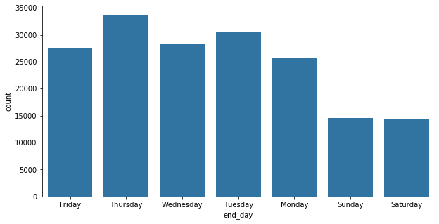

```python
# the most common end_day
plt.figure(figsize=(10,5))
base_color = sb.color_palette()[0]
sb.countplot(data=df,x='end_day',color=base_color);
```

```python
total = df['user_type'].value_counts().sum()
sub = df['user_type'].value_counts()[0]
cust = df['user_type'].value_counts()[1]

sub_prop = sub / total
cust_prop = cust / total
sub_prop
```

```
0.9053111710640633
```

```python
user_count = df['user_type'].value_counts()
```

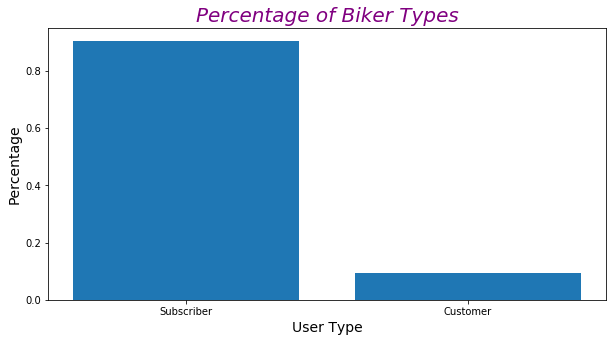

```python
plt.figure(figsize=(10,5))
plt.bar(['Subscriber','Customer'],[sub_prop, cust_prop],)
plt.title("Percentage of Biker Types",fontsize=20, fontweight=0, color='purple', style='italic')
plt.xlabel("User Type",fontsize=14)
plt.ylabel("Percentage",fontsize=14);
```

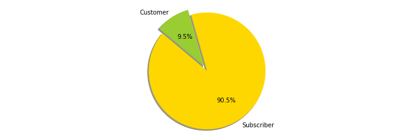

```python
# Getting the percentage
labels = 'Subscriber', 'Customer'
sizes = [sub_prop,cust_prop]
colors = ['gold', 'yellowgreen']
explode = (0.1, 0)  # explode 1st slice

# Plot
plt.pie(sizes, explode=explode, labels=labels, colors=colors,
autopct='%1.1f%%', shadow=True, startangle=140)

plt.axis('equal')
plt.show()
```

### Discuss the distribution(s) of your variable(s) of interest. Were there any unusual points? Did you need to perform any transformations?

> the unsuall points, at age column wherease 72 rows over 100 years old which is not make any sense, but i decided to keep them to not remove the whole rows or insert any random values to maintain the data credability .

### Of the features you investigated, were there any unusual distributions? Did you perform any operations on the data to tidy, adjust, or change the form of the data? If so, why did you do this?

> I did remove some unwanted columns like the longitude and latitude, and converted the birth year column to a single age number and created a new column for the age category, start and end time columns has been converted to date time to be able to extract the day and hours, and used proportion count of user type to plot as percentage.

> Convert bike Id column to a string type to be treated as category not numeric

## Bivariate Exploration

> In this section, investigate relationships between pairs of variables in your data. Make sure the variables that you cover here have been introduced in some fashion in the previous section (univariate exploration).

```python
df.groupby('member_gender')['duration_sec'].mean()
```

```
member_gender
Female    778.872761
Male      672.394851
Other     997.328489
Name: duration_sec, dtype: float64
```

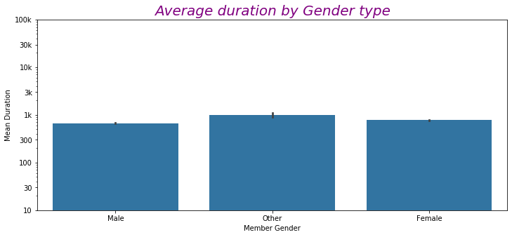

```python
# Relation between Gender and spent duration
plt.figure(figsize=(12,5))
based_color = sb.color_palette()[0]
sb.barplot(data=df,x='member_gender',y='duration_sec',color = based_color)
plt.yscale('log')
plt.yticks([10, 30, 100, 300, 1000,3000,10000,30000,100000], ['10','30','100','300', '1k','3k', '10k', '30k', '100k']);
plt.xlabel('Member Gender')
plt.ylabel('Mean Duration')
plt.title('Average duration by Gender type',fontsize=20, fontweight=0, color='purple', style='italic');
```

#### From the plot obviously that other and female gender type did spend more duration than male

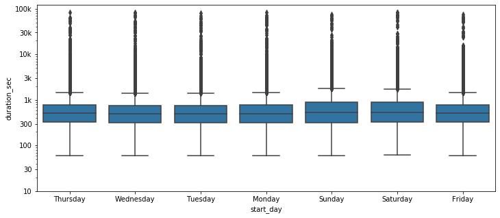

```python
#plotting week days with spent duration
plt.figure(figsize=(12,5))
based_color = sb.color_palette()[0]
sb.boxplot(data=df,x='start_day',y='duration_sec',color = based_color)
plt.yscale('log')
plt.yticks([10, 30, 100, 300, 1000,3000,10000,30000,100000], ['10','30','100','300', '1k','3k', '10k', '30k', '100k']);
```

#### Sunday and Saturday are the most days that have the highest duration trip times followed by Thursday, we are going to contribute this later with gender type and user type to see what generes are making this high variance in these two days

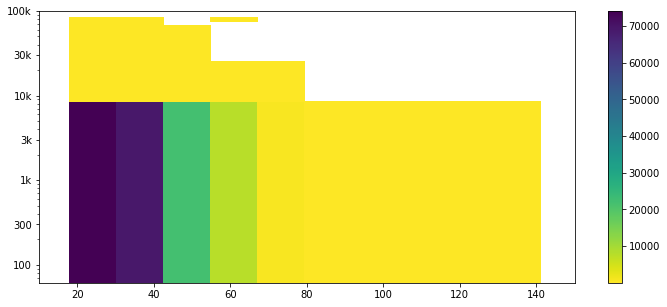

```python
# Heat map to see the age range with most duration
plt.figure(figsize=(12,5))
based_color = sb.color_palette()[0]
plt.hist2d(data=df,x='age',y='duration_sec',cmin= 0.5,cmap='viridis_r');
plt.yscale('log')
plt.xlim((10,150))
plt.colorbar();
plt.yticks([100, 300, 1000,3000,10000,30000,100000], ['100','300', '1k','3k', '10k', '30k', '100k']);
```

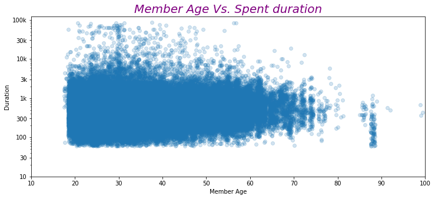

```python
plt.figure(figsize=(12,5))
based_color = sb.color_palette()[0]
sb.regplot(data=df,x='age',y='duration_sec',color = based_color,fit_reg=False,x_jitter=0.5,scatter_kws={'alpha':0.2})
plt.yscale('log')
plt.yticks([10, 30, 100, 300, 1000,3000,10000,30000,100000], ['10','30','100','300', '1k','3k', '10k', '30k', '100k']);
plt.xlim((10,100));
plt.xlabel('Member Age')
plt.ylabel('Duration')
plt.title('Member Age Vs. Spent duration',fontsize=20, fontweight=0, color='purple', style='italic');
```

### Obviuosly we can see that younger the age the more time being spent on the ride

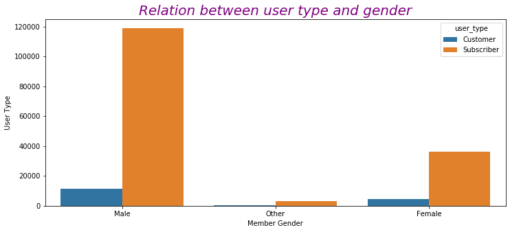

```python
# Relation between User type and Gender
plt.figure(figsize=(12,5))
based_color = sb.color_palette()[0]
sb.countplot(data=df,x='member_gender',hue='user_type')

plt.xlabel('Member Gender')
plt.ylabel('User Type')
plt.title('Relation between user type and gender',fontsize=20, fontweight=0, color='purple', style='italic');
```

### From the relationship between user type membership and gender, we found out that male subscribers are the most dominant here in the dataset comparing to the customers same for female and others.

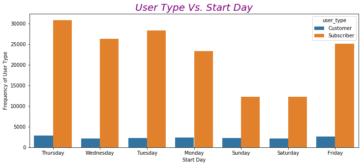

```python
# the relation bewteen user type and start day, does subscribers have certain days to go on a ride
plt.figure(figsize=(12,5))
based_color = sb.color_palette()[0]
sb.countplot(data=df,x='start_day',hue='user_type')

plt.xlabel('Start Day')
plt.ylabel('Frequency of User Type')
plt.title('User Type Vs. Start Day',fontsize=20, fontweight=0, color='purple', style='italic');
```

#### Most of the customers and subscribers prefere Thursday and Tuesday to go on a ride, and we foud no specific day for either of them to go on rather than the other type

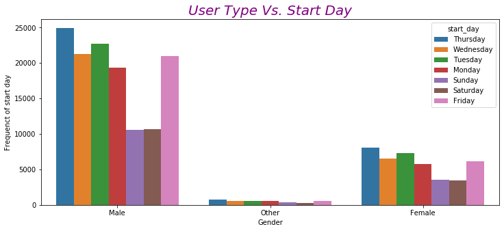

```python
# Relation between gender and start day
plt.figure(figsize=(12,5))
based_color = sb.color_palette()[0]
sb.countplot(data=df,x='member_gender',hue='start_day')

plt.xlabel('Gender')
plt.ylabel('Frequenct of start day')
plt.title('User Type Vs. Start Day',fontsize=20, fontweight=0, color='purple', style='italic');
```

#### Most common days for Males and Females are Thursday and Tuesday

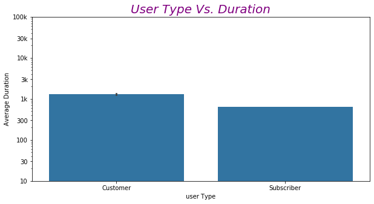

```python
# User type and Duration
plt.figure(figsize=(10,5))
based_color = sb.color_palette()[0]
sb.barplot(data=df,x='user_type',y='duration_sec',color = based_color)
plt.yscale('log')
plt.yticks([10, 30, 100, 300, 1000,3000,10000,30000,100000], ['10','30','100','300', '1k','3k', '10k', '30k', '100k']);
plt.xlabel('user Type')
plt.ylabel('Average Duration')
plt.title('User Type Vs. Duration',fontsize=20, fontweight=0, color='purple', style='italic');
```

### From the above plot Customer user type has more spent duration than subscriber user type.However, we have much more subscribers than customers

```python
# Creating Age category Column
bins=[0,18,40,60,100]

# Setting labels
labels=['teen','adult','old','Very old']
df['age_category'] = pd.cut(df['age'],bins=bins,labels=labels)
df.head()
```

|  | duration_sec | start_time | end_time | start_station_name | end_station_name | bike_id | user_type | member_birth_year | member_gender | bike_share_for_all_trip | duration_hrs | start_date | start_day | start_hour | end_date | end_day | end_hour | age | age_category |
| --- | --- | --- | --- | --- | --- | --- | --- | --- | --- | --- | --- | --- | --- | --- | --- | --- | --- | --- | --- |
| 0 | 52185 | 2019-02-28 17:32:10.145 | 2019-03-01 08:01:55.975 | Montgomery St BART Station (Market St at 2nd St) | Commercial St at Montgomery St | 4902 | Customer | 1984.0 | Male | No | 0 days 14:29:45.830000 | 2019-02-28 | Thursday | 17 | 2019-03-01 | Friday | 8 | 35.0 | adult |
| 2 | 61854 | 2019-02-28 12:13:13.218 | 2019-03-01 05:24:08.146 | Market St at Dolores St | Powell St BART Station (Market St at 4th St) | 5905 | Customer | 1972.0 | Male | No | 0 days 17:10:54.928000 | 2019-02-28 | Thursday | 12 | 2019-03-01 | Friday | 5 | 47.0 | old |
| 3 | 36490 | 2019-02-28 17:54:26.010 | 2019-03-01 04:02:36.842 | Grove St at Masonic Ave | Central Ave at Fell St | 6638 | Subscriber | 1989.0 | Other | No | 0 days 10:08:10.832000 | 2019-02-28 | Thursday | 17 | 2019-03-01 | Friday | 4 | 30.0 | adult |
| 4 | 1585 | 2019-02-28 23:54:18.549 | 2019-03-01 00:20:44.074 | Frank H Ogawa Plaza | 10th Ave at E 15th St | 4898 | Subscriber | 1974.0 | Male | Yes | 0 days 00:26:25.525000 | 2019-02-28 | Thursday | 23 | 2019-03-01 | Friday | 0 | 45.0 | old |
| 5 | 1793 | 2019-02-28 23:49:58.632 | 2019-03-01 00:19:51.760 | 4th St at Mission Bay Blvd S | Broadway at Kearny | 5200 | Subscriber | 1959.0 | Male | No | 0 days 00:29:53.128000 | 2019-02-28 | Thursday | 23 | 2019-03-01 | Friday | 0 | 60.0 | old |

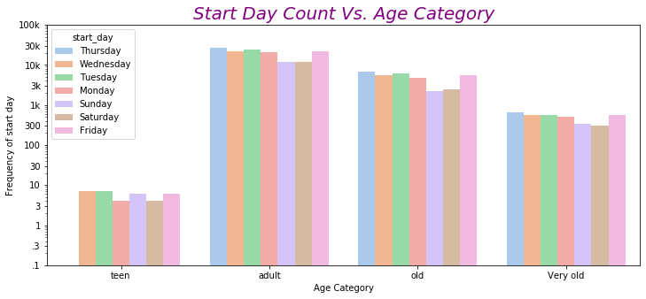

```python
# Relation between Age category and start day
# Does certain ages go on certain days
plt.figure(figsize=(12,5))
based_color = sb.color_palette()[9]
sb.countplot(data=df,x='age_category',hue='start_day',palette= 'pastel')

plt.yscale('log')
plt.yticks([.1,.3,1,3,10, 30, 100, 300, 1000,3000,10000,30000,100000], ['.1','.3','1','3','10','30','100','300', '1k','3k', '10k', '30k', '100k']);
plt.xlabel('Age Category')
plt.ylabel('Frequency of start day')
plt.title('Start Day Count Vs. Age Category',fontsize=20, fontweight=0, color='purple', style='italic');
```

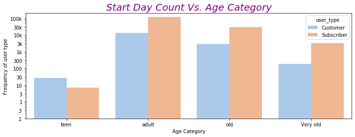

```python
#Plotting user type and age category
based_color = sb.color_palette()[9]
sb.countplot(data=df,x='age_category',hue='user_type',palette= 'pastel')

plt.yscale('log')
plt.yticks([.1,.3,1,3,10, 30, 100, 300, 1000,3000,10000,30000,100000], ['.1','.3','1','3','10','30','100','300', '1k','3k', '10k', '30k', '100k']);
plt.xlabel('Age Category')
plt.ylabel('Frequency of user type')
plt.title('Start Day Count Vs. Age Category',fontsize=20, fontweight=0, color='purple', style='italic');
```

#### From this plot, all age groups have higher subscribers than customers except for teens category customers number is higher

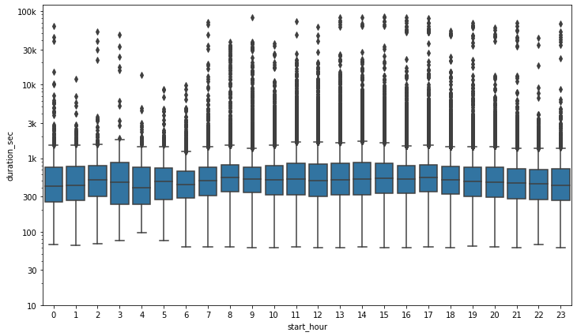

```python
# Start hour and duration
base_color=sb.color_palette()[0]
plt.figure(figsize=(12,7))
sb.boxplot(data=df,x='start_hour',y='duration_sec',color=base_color)
plt.yscale('log')
plt.yticks([10, 30, 100, 300, 1000,3000,10000,30000,100000], ['10','30','100','300', '1k','3k', '10k', '30k', '100k']);
```

### Obviously the morning start hour tends to has higher duration spent on the trip

```python
count_names = df['start_station_name'].value_counts()
threshold = 2000
idx = np.sum(count_names > threshold)
most_station = count_names.index[:idx]
```

```python
df_sub = df.loc[df['start_station_name'].isin(most_station)]
```

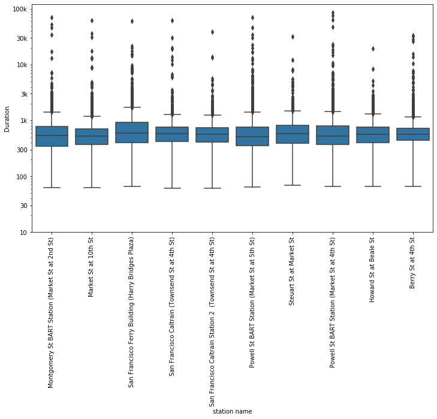

```python
# Start hour and start location
base_color=sb.color_palette()[0]
plt.figure(figsize=(12,7))
sb.boxplot(data=df_sub,x='start_station_name',y='duration_sec',color=base_color)
plt.xlabel('station name')
plt.ylabel('Duration')
plt.xticks(rotation=90)
plt.yscale('log')
plt.yticks([10, 30, 100, 300, 1000,3000,10000,30000,100000], ['10','30','100','300', '1k','3k', '10k', '30k', '100k']);
```

### start station san francisco ferry building is one of the most start staions the bikers begins with and spent the highest duration.

### Talk about some of the relationships you observed in this part of the investigation. How did the feature(s) of interest vary with other features in the dataset?

> We found that (other gender type did the highest duration trip time), followed by female, and men are the last in duration frequecy, from scatterplot of age and duration we found that the younger the age the most duration has been spent on the trip, subscriber numbers are higher in the three gender types than customers.

> Customer user type did higher duration trip than subscribers, although the very high perecntage of subscribers. The earlier the start hour the more duration the biker tend to spend, and the most common start station that biker starts from and spend the longest duration is (San franscisco Ferry Building(harry Bridges Plaza).

### Did you observe any interesting relationships between the other features (not the main feature(s) of interest)?

> Despite the high perecntage of male in the datasetset, but Female and other spent more duration during trip, that customers membership type also did a higher duration than subscribers That when we categorized the age we found new common start days

## Multivariate Exploration

> Create plots of three or more variables to investigate your data even further. Make sure that your investigations are justified, and follow from your work in the previous sections.

#### let's Check after we found out that sunday an saturday are the days that has the most spent duration and from univariate gender type plot we found that other gender has the most spent duration as well.

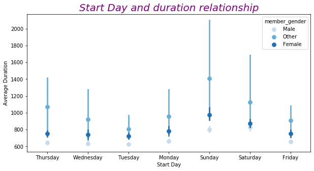

```python
# plotting start day and average duration with gender
plt.figure(figsize=(10,5))
sb.pointplot(data =df, x = 'start_day', y = 'duration_sec',
           palette = 'Blues', linestyles = '',hue='member_gender')


plt.xlabel('Start Day')
plt.ylabel('Average Duration')
plt.title('Start Day and duration relationship',fontsize=20, fontweight=0, color='purple', style='italic');
```

#### From the above pointplot, Other and Female gender types spent the highest duration on sunday and saturday, which causes that sundays and saturdays has the highest duration spent during the whole week.

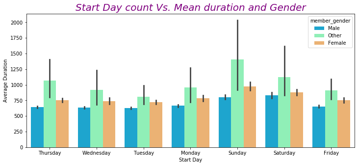

```python
# Plot start day and duration with Gender type in barplot
plt.figure(figsize=(12,5))
sb.barplot(data = df,x='start_day',y='duration_sec',hue='member_gender',palette='rainbow')

#plt.yscale('log')
plt.xlabel('Start Day')
plt.ylabel('Average Duration')
plt.title('Start Day count Vs. Mean duration and Gender',fontsize=20, fontweight=0, color='purple', style='italic');
```

#### As we can see from the pointplot and the barplot that sunday and saturday has the most spent duration that other and female bikers prefere to go on a ride on Sunday and Saturday causing the most duration times through these days

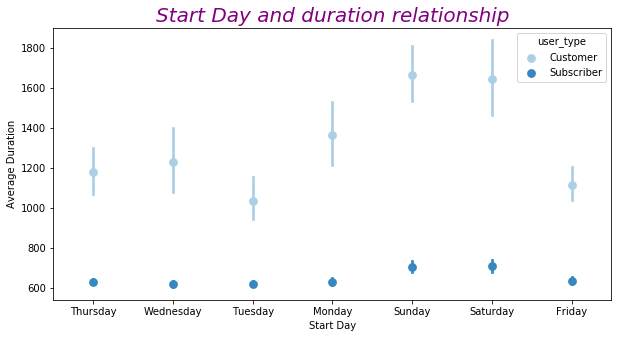

```python
# Plot start day and duration by user type
plt.figure(figsize=(10,5))
sb.pointplot(data =df, x = 'start_day', y = 'duration_sec',
           palette = 'Blues', linestyles = '',hue='user_type')


plt.xlabel('Start Day')
plt.ylabel('Average Duration')
plt.title('Start Day and duration relationship',fontsize=20, fontweight=0, color='purple', style='italic');
```

### From this plot we can get the insight of the user type who spend more duration and the days spent on the most as well as we interpreted before, this plot to assure that customer is spending more time during trip than subscriber on sundays and saturdays the most

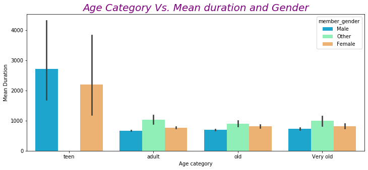

```python
# Age category, duration and Gender relationship
plt.figure(figsize=(12,5))
sb.barplot(data = df,x='age_category',y='duration_sec',hue='member_gender',palette='rainbow')


plt.xlabel('Age category')
plt.ylabel('Mean Duration')
plt.title('Age Category Vs. Mean duration and Gender',fontsize=20, fontweight=0, color='purple', style='italic');
```

### From this barplot we can figure that teen age until 18 years old has no other type gender, and male teen spend more time during trip than female and teen category in general has the most duration time which make sense.However, (other gender type) as mentioned before has the most spent duration trips in Adult category and older. followed by females

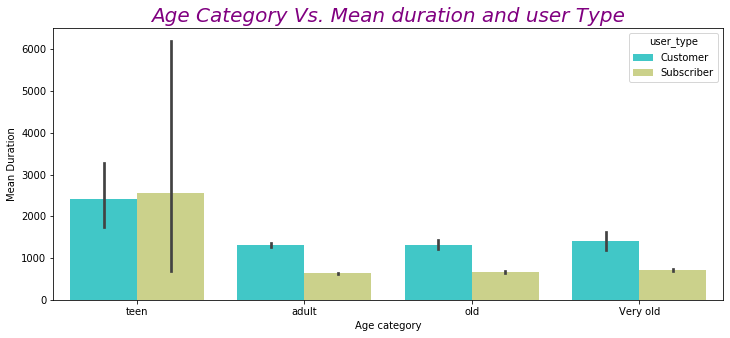

```python
plt.figure(figsize=(12,5))
sb.barplot(data = df,x='age_category',y='duration_sec',hue='user_type',palette='rainbow')


plt.xlabel('Age category')
plt.ylabel('Mean Duration')
plt.title('Age Category Vs. Mean duration and user Type',fontsize=20, fontweight=0, color='purple', style='italic');
```

### customers from adult and older spend more time during trip than subscribers from adult and older which reconfirom that customers at all spend more time during trip much more than subscribers, excxept for the teen category (until 18 YO) subscriber teens spent more duration than customers

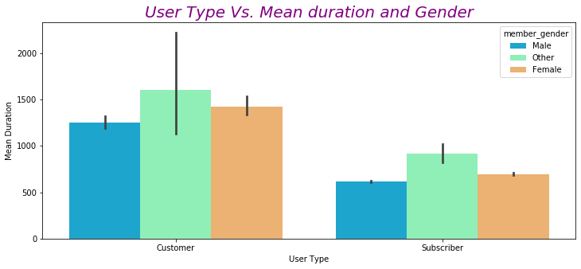

```python
# User Type, gender and duration relationship
plt.figure(figsize=(12,5))
sb.barplot(data = df,x='user_type',y='duration_sec',hue='member_gender',palette='rainbow')


plt.xlabel('User Type')
plt.ylabel('Mean Duration')
plt.title('User Type Vs. Mean duration and Gender',fontsize=20, fontweight=0, color='purple', style='italic');
```

### The customer user type has the highest duration all over three types gender, and specifically the highest duration spent as mentioned before belongs to other and female gender type

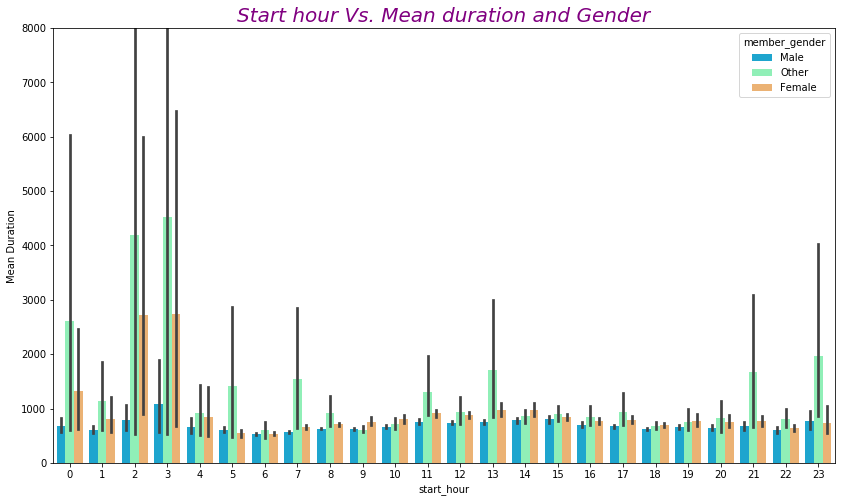

```python
plt.figure(figsize=(14,8))
sb.barplot(data = df,x='start_hour',y='duration_sec',hue='member_gender',palette='rainbow')


plt.xlabel('start_hour')
plt.ylabel('Mean Duration')
plt.title('Start hour Vs. Mean duration and Gender',fontsize=20, fontweight=0, color='purple', style='italic');
plt.ylim((0,8000));
```

### This plot assure that female and other type gender have the highest duration time. Moreover, starting hours around 2 and 3 Am ahs the most duration time , which in conclusion made it clear about that the gender who did the most duration actually fall in the same start hour zone of the most duration which we clarified before that most duration hourrs spent belongs to riders start the trip from 2 or 3 am

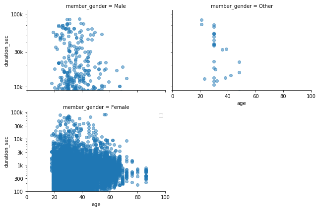

```python
# plotting the three genders together with age and duration
plt.figure(figsize=(10,5))
g=sb.FacetGrid(data=df,col='member_gender',col_wrap=2,size=3,aspect=1.5)
g.map(plt.scatter,'age','duration_sec',alpha=.5);
plt.legend()
plt.yscale('log')
plt.yticks([100, 300, 1000,3000,10000,30000,100000], ['100','300', '1k','3k', '10k', '30k', '100k']);
plt.xlim((0,100));
```

#### This 3 plots shows more density at upper left portion of female scatter plot than male, but it doesnt show it properly for other gender type due to the low count of pther in the data set but we did observed that other has the highest duration spent from barplots

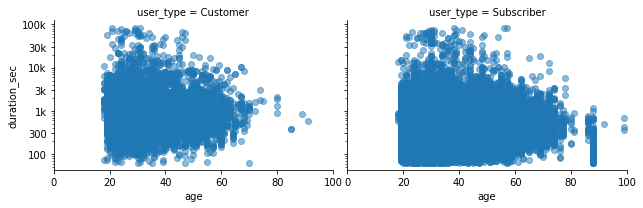

```python
plt.figure(figsize=(10,5))
g=sb.FacetGrid(data=df,col='user_type',size=3,aspect=1.5)
g.map(plt.scatter,'age','duration_sec',alpha=.5);

plt.yscale('log')
plt.yticks([100, 300, 1000,3000,10000,30000,100000], ['100','300', '1k','3k', '10k', '30k', '100k']);
plt.xlim((0,100));
```

#### reconfirmation by scatterplots for customer and subscriber, as we can see the upper left portion in customer plot higher in density than subscriber user type.

#### From thhese scatter plots we can see that subscribers age range is wider than customer age range

```python
count_names = df['start_station_name'].value_counts()
threshold = 2000
idx = np.sum(count_names > threshold)
most_station = count_names.index[:idx]


#count_names_end = df['end_station_name'].value_counts()
#threshold = 2000
#idx2 = np.sum(count_names_end > threshold)
#most_station_end = count_names_end.index[:idx2]
```

```python
df_sub = df.loc[df['start_station_name'].isin(most_station)]
df_sub2 = df.loc[df['end_station_name'].isin(most_station_end)]
```

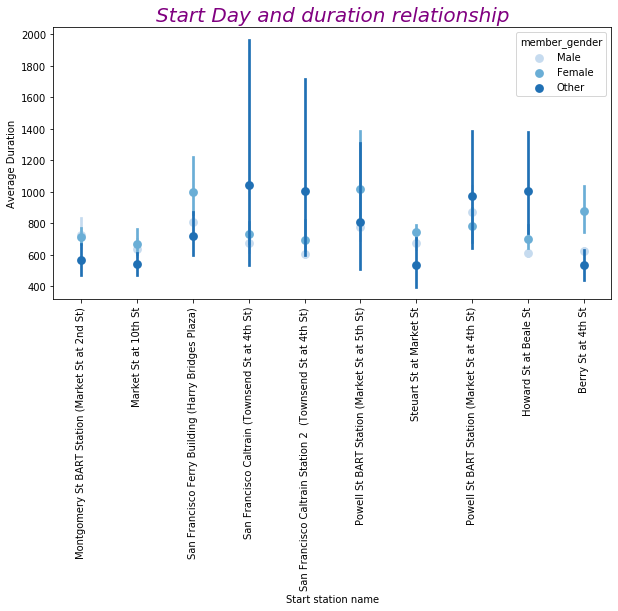

```python
plt.subplots(figsize=(10,5))
sb.pointplot(data =df_sub, x = 'start_station_name', y = 'duration_sec',
           palette = 'Blues', linestyles = '',hue='member_gender')


plt.xlabel('Start station name')
plt.xticks(rotation=90)
plt.ylabel('Average Duration')
plt.title('Start Day and duration relationship',fontsize=20, fontweight=0, color='purple', style='italic');
```

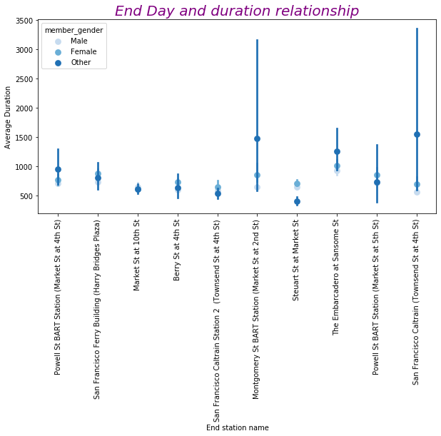

```python
plt.subplots(figsize=(10,5))
sb.pointplot(data =df_sub2, x = 'end_station_name', y = 'duration_sec',
           hue='member_gender',palette = 'Blues', linestyles = '',dodge=False)


plt.xlabel('End station name')
plt.xticks(rotation=90)
plt.ylabel('Average Duration')
plt.title('End Day and duration relationship',fontsize=20, fontweight=0, color='purple', style='italic');
```

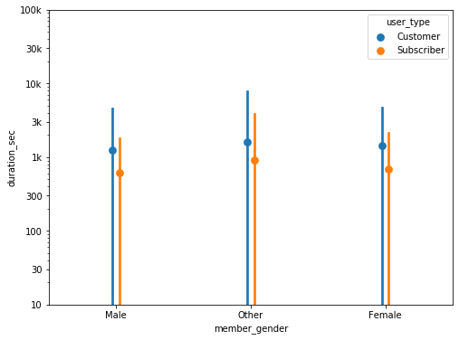

```python
#plotting gender,user type and duration
plt.figure(figsize = [8,6])

ax = sb.pointplot(data =df, x = 'member_gender', y = 'duration_sec', hue = 'user_type',ci='sd',dodge=True,linestyles=" ")


plt.yscale('log')
plt.yticks([10, 30, 100, 300, 1000,3000,10000,30000,100000], ['10','30','100','300', '1k','3k', '10k', '30k', '100k']);
ax.set_yticklabels([], minor = True)

plt.show();
```

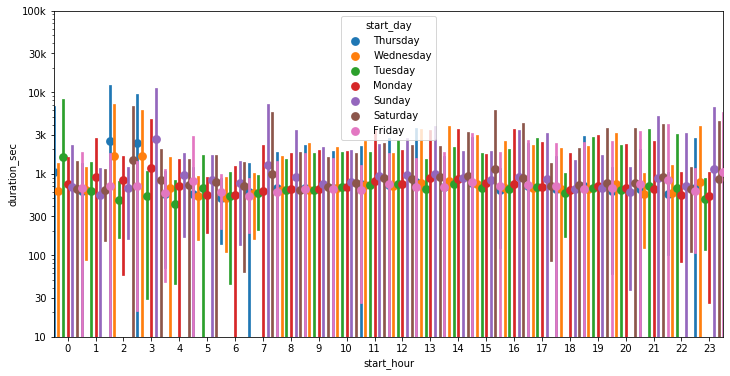

```python
plt.figure(figsize = [12,6])

ax = sb.pointplot(data =df, x = 'start_hour', y = 'duration_sec', hue = 'start_day',ci='sd',dodge=1,linestyles=" ")


plt.yscale('log')
plt.yticks([10, 30, 100, 300, 1000,3000,10000,30000,100000], ['10','30','100','300', '1k','3k', '10k', '30k', '100k']);
ax.set_yticklabels([], minor = True)

plt.show();
```

### Were there any interesting or surprising interactions between features?

> Teens have more customer types than subscribers which is not surorise due to the young age and less indpendency to subscribe, but what was interseting that customer type making higher duration trips than subscriber type member in all categories except for teens from (0-18), Also despite males have the largest count on the dataset about 75%, other and female gender type did the highest duration trips

> At the end of your report, make sure that you export the notebook as an html file from the `File > Download as... > HTML` menu. Make sure you keep track of where the exported file goes, so you can put it in the same folder as this notebook for project submission. Also, make sure you remove all of the quote-formatted guide notes like this one before you finish your report!